# Statical Methods for Data Science: Laboratory 2

Central Limit Theorem, distribution of sample statistics and point estimation

N Torelli, G Di Credico, V Gioia

26 October 2022

# Central Limit Theorem (CLT)

Let $X_1, X_2, \ldots, X_n$, be a sequence of independent and identically distributed (iid) random variables (rv) from a distribution with mean $\mu$ and finite variance $\sigma^2$.

For large n, the sample average
$$\bar X = \frac{1}{n} \sum_{i=1}^{n}X_i \, \dot \sim \, \mathcal{N}(\mu, \sigma^2/n)$$
where $\dot \sim$ indicates convergence in distribution. Equivalently
$$S_n = \sum_{i=1}^{n}X_i \, \dot \sim \, \mathcal{N}(n\mu, n\sigma^2)$$
The CLT supports the normal approximation to the distribution of a rv that can be viewed as the sum of other r.v.

## Approximation with CLT: application

The approximation above is useful in statistics for computing some quantities. For instance, let $X$ and $Y$ be two independent Binomial rv, such that $X \sim Bin(n,p)$ and $Y \sim Bin(m, q)$.

We are interested in computing the probability
$$P(X>Y)=?$$

Normal approximation is the simplest way to do it. We can approximate:
$$X \, \approx \, {\cal N}(np, np(1-p)), \quad \quad \quad \ Y \, \approx \, {\cal N}(mq, mq(1-q))$$
.

Then, by using a well known probability result, the difference $W=X-Y$ of two independent normal distributions with means $\mu_X, \mu_Y$ and variances $\sigma^2_X, \sigma^2_Y$, respectively, is **still a normal distribution** with mean $\mu_W=\mu_X-\mu_Y$ and variance $\sigma^2_W=\sigma^2_X+\sigma^2_Y$.

In such a case,
$$\mu_W=\mu_X-\mu_Y= np-mq, \quad \quad \quad \sigma^2_W=\sigma^2_X+\sigma^2_Y=np(1-p)+mq(1-q).$$

## Approximation with CLT: real application with waterpolo goals

Tomorrow two professional Italian waterpolo teams, Posillipo and Pro Recco, compete against each other: $X$ and $Y$ are the random *goals scored* by both the teams.

We assume that $X, Y$ follow two independent Binomial distributions: precisely, $X, Y$ represent the number of shots converted in goal on the total number of shots $n, m$ made by Posillipo and Pro Recco , with probabilities $p$ and $q$, respectively.

Before the match, the number of shots is *unknown*. In what follows, we adopt a simplification, and we treat the quantities $p,q,m,n$ as *known*, for instance fixing them upon historical experience: $p=0.5, q=0.7, n=20, m=20$.

We want to investigate the Posillipo probability of winning the next match against Pro Recco,
$$P(X>Y)=P(X-Y>0)=?$$

```r
p <- 0.5
q <- 0.7
n <- m <-20
mW <-  p * n - q * m
sdW <- sqrt( n * p * (1 - p) + m * q * (1 - q) )
# Probability that  W = X-Y > 0 (Posillipo win the match)
PWin_P <- pnorm(0, mean = mW, sd = sdW, lower.tail = FALSE)
PWin_P
```

```
## [1] 0.09362452
```

Here, we show the probability mass functions of $X$ and $Y$ and the probability density function of $W=X-Y$.

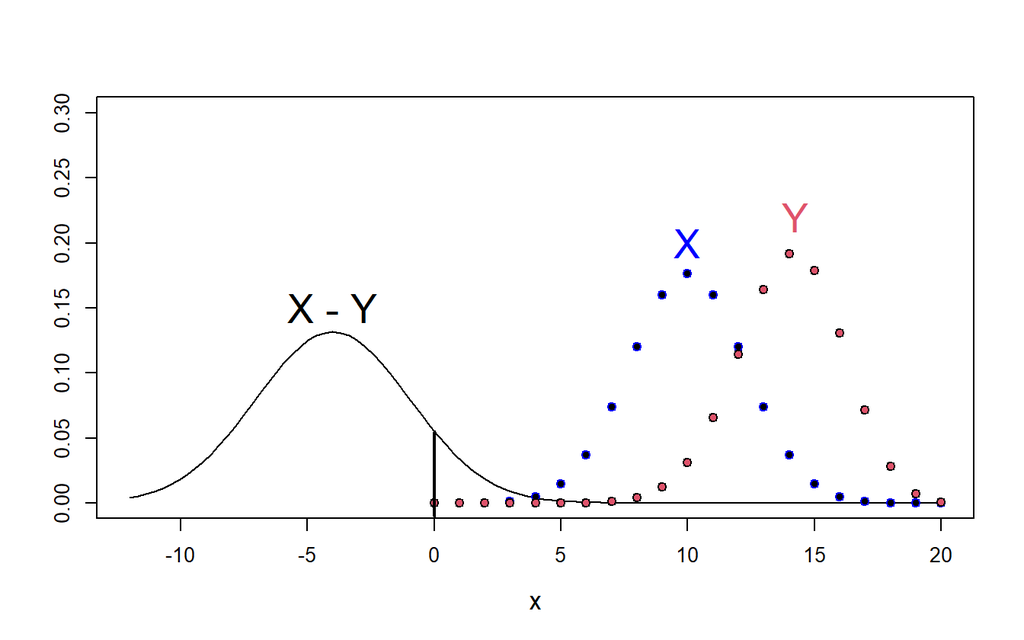

```r
# pdf of W
curve(dnorm(x, mW, sdW),
      xlim = c(-12, 20), ylim = c(0, 0.3), ylab = "", cex.lab = 1.25)

# pmf of X and Y and
points(0 : 20, dbinom(0 : n, n, p), pch = 21, bg = 1, col = "blue")
points(0 : 20, dbinom(0 : m, m, q), pch = 21, bg = 2)

segments(0, -0.01,              #(x_0, y_0)
         0, dnorm(0, mW, sdW),  #(x_1, y_1)
         lwd = 2)

text(14.25, 0.22, "Y", cex = 2, col = 2)
text(10, 0.2, "X", cex = 2, col = "blue")
text(-4, 0.15, "X - Y", cex = 2, col = 1)
```

*Note*: when discrete distributions are approximated by continuous distributions, it is a good practice to apply a *continuity correction* (c.c.). In this case: $P(X>Y) \approx P(W>0) \stackrel{c.c.}{\approx} P(W > 0.5)$.

```r
# Probability that Posillipo win the match, taking into account the continuity correction
PWin_P_cc <-  pnorm(0.5, mean = mW, sd = sdW, lower.tail = FALSE)
PWin_P_cc
```

```
## [1] 0.06895673
```

## Waterpolo goals: what if we use a Poisson distribution?

Rather than specifying in advance the total number of unknown shots and the converting shots probabilities, i.e. 4 parameters, one coud be tempted to use a more flexible distribution accounting just fot the *scoring intensity*, regardless of the number of shots.

For this purpose, the Poisson distribution seems suitable. We may assume two independent Poisson distributions for the number of goals of the upcoming match: $X\sim \mathcal{P}(\lambda), \ Y \sim \mathcal{P}(\mu)$.

At this stage, in order to make the same prediction as before, we need to specify the rates, for instance upon our own knowledge about waterpolo abilities: $\lambda=5, \mu=7$.

How can we estimate now the winning probability for Posillipo, $P(X>Y)=P(X-Y>0)$?

We may use the following probability result: $Z = X-Y \sim \mathcal{PD}(\lambda-\mu, \lambda+\mu)$, where $\mathcal{PD}$ stands for the **Poisson difference** distribution, also known as **Skellam** distribution, with mean $\lambda-\mu$ and variance $\lambda+\mu$. (see e.g. https://www.jstor.org/stable/2981372)

```r
# Probability that Posillipo win the match, by using the Skellam distribution
library(skellam)
lambda <- 5
mu <- 7

PWin_P_sk <- pskellam(0, lambda, mu, lower.tail = FALSE)
PWin_P_sk
```

```
## [1] 0.2336875
```

**It’s your turn**

With the same settings above ($\lambda=5, \mu=7$), try to use the normal approximation of the Poisson distribution (if $X \sim Poisson(\lambda)$, for large $\lambda$, it holds $X \approx \cal{N}(\mu = \lambda, \sigma^2 = \lambda),$) to compute the winning probability for Posillipo and compare the results with those obtained by using the Skellam distribution. What happens with or without the continuity correction? Then, plot the probability mass functions of $X$, $Y$ and $Z$. Try to overlap also the normal approximation that you obtained.

```r
# Probability that Posillipo win the match, by using the normal approximation to the Poisson distribution
mZ <- lambda - mu
sdZ <- sqrt(lambda + mu)

# Without continuity correction
PWin_P_napp <- pnorm(0, mZ , sdZ, lower.tail = FALSE)
PWin_P_napp
```

```
## [1] 0.2818514
```

```r
# With continuity correction
PWin_P_napp_cc <- pnorm(0.5, mZ , sdZ, lower.tail = FALSE)
PWin_P_napp_cc
```

```
## [1] 0.2352432
```

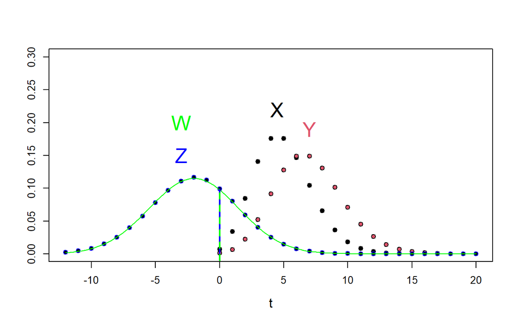

```r
# pmf of X
plot(0 : 20, dpois(0 : 20, lambda), xlim = c(-12, 20),
     ylim=c(0, 0.3), ylab = "", xlab = "t",
     pch = 21, bg = 1, cex.lab = 1.25)
# pmf of Y
points(0 : 20, dpois(0 : 20, mu), pch = 21, bg = 2)
# pmf of Z
points(-12 : 20, dskellam(-12 : 20, lambda, mu), pch = 21, bg = 1, col = "blue" )

# pdf of W
curve(dnorm(x, mZ, sdZ), add = TRUE, col = "green")

segments(0, -0.01,                    #(x_0, y_0)
         0, dskellam(0, lambda, mu),  #(x_1, y_1)
         lwd = 2,col="blue" )
segments(0, -0.01,
         0, dnorm(0, mZ, sdZ),
         lwd = 2, col = "green", lty = "dashed")

text(4.5, 0.22, "X", cex = 2, col = 1)
text(7, 0.19, "Y", cex = 2, col = 2)
text(-3.0, 0.15, "Z", cex = 2, col = "blue")
text(-3.0, 0.20, "W", cex = 2, col = "green")
```

# Distribution of the sample mean

Suppose that $Y_1, \ldots, Y_n$ sequence of iid rv from

- Case 1: $\mathcal{N}(0,1)$ (i.e. standard normal);
- Case 2: $\mathcal{t}_{3}$ ($t$-student with 3 degrees of freedom);
- Case 3: $\mbox{Unif}(0,1)$ (i.e. standard continuous uniform).

Which is the distribution of the sample mean $\overline{Y}=\frac{1}{n}\sum_{i=1}^{n}Y_{i}$?

Before answering, let’s investigate this issue via simulation, with number of simulations $R=1000$ and sample size $n=30$.

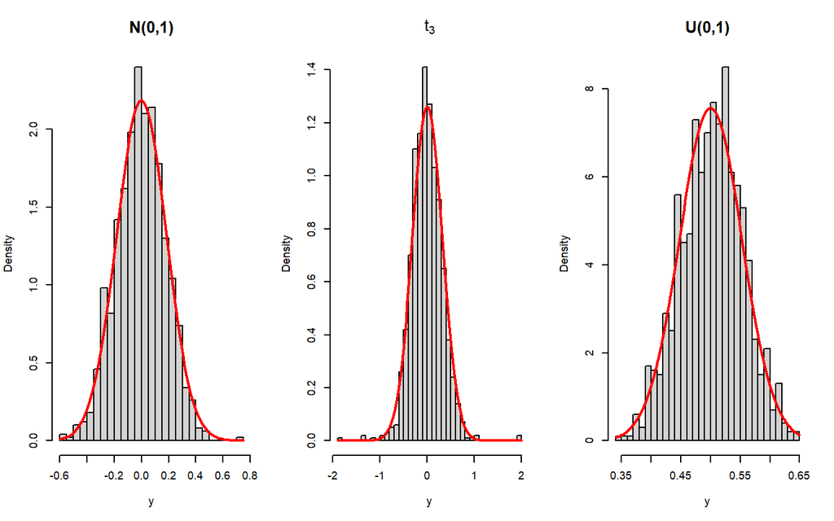

```r
set.seed(1234)
R <- 1000
n <- 30

#generate the sample of size n (from the distribution aforementioned) R times
samples <- array(0, c(3, R, n))
  for (i in 1:R){
    samples[1, i, ] <- rnorm(n, 0, 1)
    samples[2, i, ] <- rt(n, df = 3)
    samples[3, i, ] <- runif(n, 0, 1)
  }


#compute the sample mean and the sample variance
samples_stat <- array(0, c(3, 2, R))
for (j in 1 : 3) {
  samples_stat[j, 1, ] <- apply(samples[j, , ], 1, mean)
  samples_stat[j, 2, ] <- apply(samples[j, , ], 1, var)
}

#visualize the results
par (mfrow=c(1,3))

hist(samples_stat[1, 1, ], nclass = 30, probability = TRUE,
     xlab="y", main= "N(0,1)", cex.main = 1.5)
curve(dnorm(x, 0, sqrt(1/n)), add = TRUE, col = "red", lwd = 2)

hist(samples_stat[2, 1, ], nclass = 30, probability = TRUE,
     xlab = "y", main = expression(t[3]), cex.main = 1.5)
curve(dnorm(x, 0, sqrt(  (3/((3 - 2) * n)))), add = TRUE, col = "red", lwd = 2)

hist(samples_stat[3, 1, ], nclass = 30, probability = TRUE,
     xlab = "y", main = "U(0,1)", cex.main = 1.5)
curve(dnorm(x, 1/2, sqrt(1/(12 * n))), add = TRUE, col = "red", lwd = 2)
```

In the Gaussian case the **sample mean** $\overline Y$ for iid values still follows a normal distribution, precisely $\mathcal{N}(\mu, {\sigma^{2}}/{n})$.

For other distributions, this result is true only asymptotically, when $n \rightarrow \infty$, due to the CLT theorem. When the sampling does not come from a Normal distribution $\overline{Y} \overset{\cdot}{\sim} \mathcal{N}(\mu, {\sigma^{2}}/{n})$.

# Distribution of the sample variance in the normal case

We know that $S^{2}= \frac{1}{n-1} \sum_{i=1}^{n}(Y_{i}-\bar{Y})^{2}$ is an unbiased estimator for the variance (An estimator is said to be **unbiased** iff $E(\widehat{{\theta}})= {\theta}.$), and this is exactly the output provided by $\mathsf{R}$ through the function $\mathsf{var()}$ applied to a sample vector.

In the example above, we have already stored the variance. If the assumed true model is normal, we know that the distribution of the sample variance is proportional to a $\chi^{2}$ distribution with $n-1$ degrees of freedom:

$$\frac{(n-1)S^2}{\sigma^2} \sim \chi^{2}_{n-1}$$

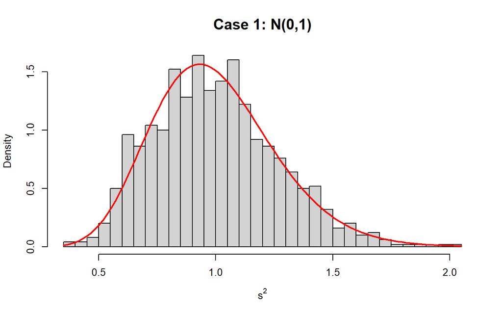

```r
#visualize the results: variance
par (mfrow=c(1,1))
sigma <- 1
hist(samples_stat[1, 2, ], nclass = 30, probability = TRUE,
     xlab=expression(s^2), main = "Case 1: N(0,1)", cex.main = 1.5)
curve(((n - 1)/sigma^2) * dchisq(x * ((n - 1)/sigma^2), df = n - 1),
      add = TRUE, col = "red", lwd = 2)
```

**Note**
Let $X$ a r.v. with pdf $f_X(x)$, then $Y=g(X)$, with $g(\cdot)$ an invertible function, has pdf
$$f_Y(y)=f_X(g^{-1}(y))\Bigg | \frac{d}{dy} g^{-1}{(y)}\Bigg |$$
So, in our case let $X=\frac{(n-1)S^2}{\sigma^2} \sim \chi^2_{n-1}$, then $S^2=Y=\frac{\sigma^2}{n-1} X$ is such that
$$f_Y(y)= f_X \Big(\frac{n-1}{\sigma^2}y \Big) \frac{n-1}{\sigma^2},$$

since $g^{-1}(y) = \frac{n-1}{\sigma^2}y$ and $\frac{d}{dy} g^{-1}{(y)}=\frac{n-1}{\sigma^2}$

**Extra Exercise: sample variance distribution in non normal cases**

Consider the following paper to understand the distribution of the sample variance for the case of the non normal distributions.  
https://www.tandfonline.com/doi/abs/10.1080/00031305.2014.966589 (in the Lab2 folder you can find the pdf version)

Then, visualize the sample distribution of the sample variances for the case 2 and 3 via histograms; overlap the probability density function of the sample variance estimators according to the results of the paper aforementioned and compare them with those obtained by considering the distribution of the sample variance for the normal case.

# Basic concepts of estimation

## Point estimation

Let $\hat \theta$ be the point estimator for the parameter $\theta$. An estimator is said to be

- **unbiased** if and only if $E(\hat \theta)=\theta$
- **consistent** if $\hat \theta \stackrel{P}\rightarrow \theta$, as $n \rightarrow \infty$ or, equivalently, if $\text{var}(\hat \theta) \rightarrow 0$, as $n \rightarrow \infty$.

There are some properties that we would ensure for an estimator: **low variance** and **low bias**. But, there is a tradeoff between unbiasedness and low variance, so we would usually seek to get both (to some extent); ideally, we would target a small **Mean Squared Error** (**MSE**)

$$\rm{MSE}(\hat \theta)=E\{(\hat \theta-\theta)^2 \}= \{E(\hat \theta) - \theta\}^2+var(\hat \theta)=(Bias)^2+Variance$$

### Application: Comparison of unbiased and biased sample variance estimators

Related to the distribution of the sample variance in the normal case, we could also rely on the biased estimator $S^{2}_{b}= \frac{1}{n}\sum_{i=1}^{n}(Y_{i}-\bar{Y})^{2}$.

Check the biased nature of $S^{2}_b$ via MC simulation, generating $n = 10$ iid values from a normal distribution. Compare the results with the unbiased estimator $S^{2}$

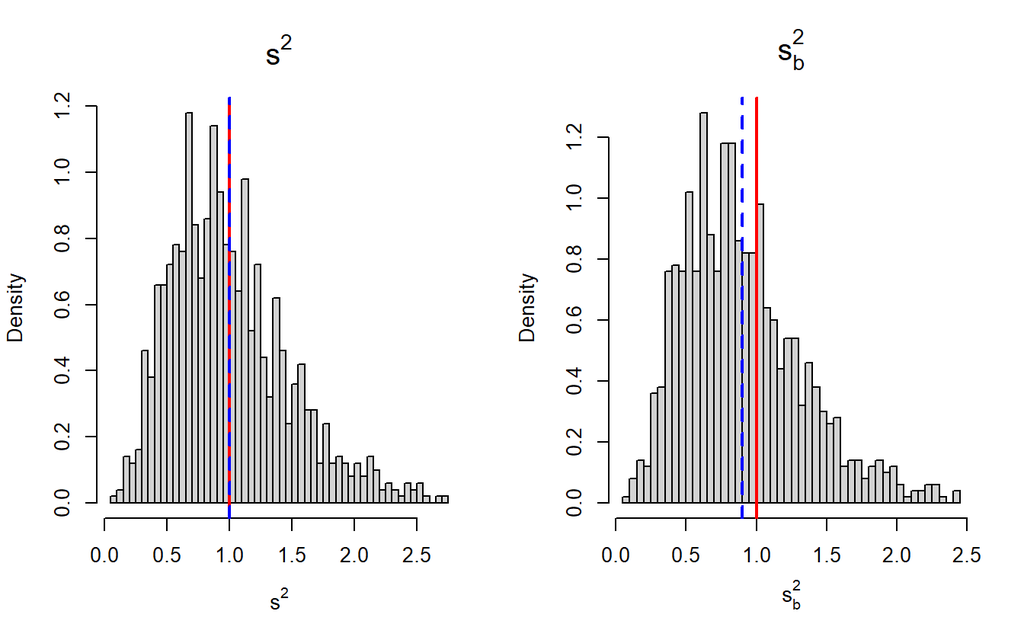

```r
#Initial settings:
# Number of replications B = 10000
# Sample size n = 10
# Population mean = 0
# Population variance = 1
set.seed(2)
R <- 1000
n <- 10
mu <- 0
sigma <- 1


# Save the results in two vectors:
# s2: unbiased sample variance estimates
# s2_b: biased sample variance estimates
s2 <- rep(0, R)
s2_b <- rep(0, R)

# For each replication we generate 10 samples from
# a normal r.v. with mean mu and variance sigma^2
# and we compute the four sample variance estimates
for ( i in 1 :R ) {
  y <- rnorm(n, mu, sigma)
  s2[i] <- var(y)
  s2_b[i] <- var(y)*(n-1)/n
    }

s2_mean <- mean(s2)
s2_b_mean <- mean(s2_b)

#plot s2
par(mfrow=c(1,2), oma=c(0,0,0,0))
hist(s2, breaks = 50, xlab = expression(s^2), probability = TRUE,
     main = expression(s^2), cex.main = 1.5)
#in red the true mean, in blue the estimated mean
abline(v = sigma^2, col = "red", lwd = 2)
abline(v = s2_mean, col = "blue", lwd = 2, lty = 2)

#plot s2 biased
hist(s2_b, breaks = 50, xlab = expression(s[b]^2), probability = TRUE,
     main = expression(s[b]^2), cex.main = 1.5)
#in red the true mean, in blue the estimated mean
abline(v = sigma^2, col = "red", lwd = 2)
abline(v = s2_b_mean, col = "blue", lwd = 2, lty = 2)
```

### Application: Comparison of four estimators of the population mean

As we already know from the theory, the sample mean is an excellent estimator for the population mean. But we will consider now other estimators. Consider the case of a normal distribution $\mathcal{N}(\mu, \sigma^2)$ and the following estimators:

- sample mean:
  $$\hat \mu_1=\frac{1}{n}\sum_{i=1}^{n}x_i$$
- sample median:
  $$\hat \mu_2= \text{Median}(x)$$
- the semi-sum of the sample minimum and the maximum
  $$\hat \mu_3=\frac{\min(x)+\max(x)}{2}=\frac{x_{(1)}+x_{(n)}}{2}$$
- the 10% trimmed sample mean: the idea of the trimmed sample mean is to compute the mean discarding the 10% of data from the lower tail and the 10% from the upper tail (the following definition covers only the case when $n$ is even and $0.1n$ is an integer)
  $$\hat \mu_4=\frac{1}{0.8n}\sum_{i=0.1n}^{0.9n}x_{(i)}$$

with $x_{(i)}$ the $i$-th order statistic.

We aim to compare the four estimators in terms of unbiasedness and efficiency.

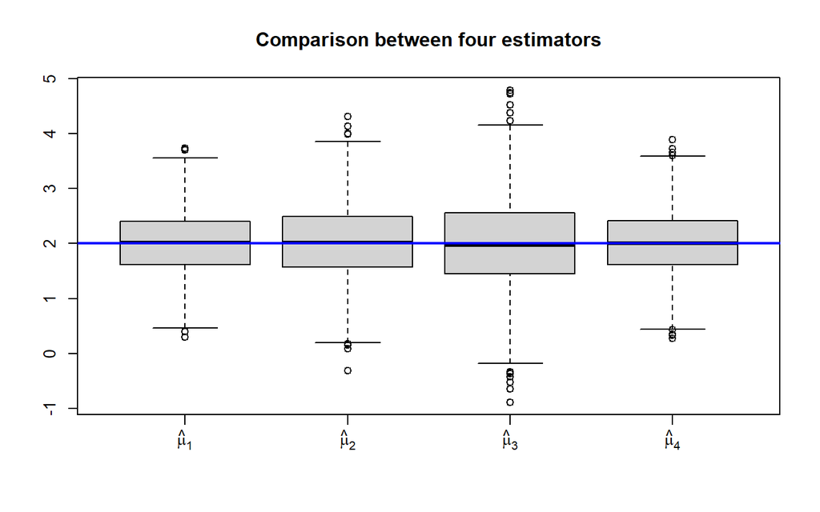

```r
#Initial settings:
# Number of replications B = 10000
# Sample size n = 10
# Population mean = 2
# Population variance = 4

R <- 1000
n <- 10
mu <- 2
sigma <- 2

# Save the results in a matrix:
# Column 1: sample mean
# Column 2: sample median
# Column 3: semi-sum of minumu and maximum
# Column 4: trimmed sample mean
est <- matrix(0, R, 4)

set.seed(1234)
# For each replication we generate 10 samples from
# a normal r.v. with mean mu and variance sigma^2
# and we compute the four sample estimate
for ( i in 1 : R ) {
 x <- rnorm(n, mu, sigma)
 est[i, 1] <- mean(x)
 est[i, 2] <- median(x)
 est[i, 3] <- (min(x) + max(x))/2
 est[i, 4] <- mean(x, trim = 0.1)
}

# By using the boxplot, we plot the distribution of the sample estimate
# Blue horizontal line is the true population mean
par(mfrow = c(1, 1), xaxt = "n")
boxplot(est, main="Comparison between four estimators")
par(xaxt = "s")
axis(1, 1:4, c(expression(hat(mu)[1]), expression(hat(mu)[2]), expression(hat(mu)[3]), expression(hat(mu)[4])) )
abline(h = mu, lwd = 2, col = "blue")
```

```r
# Bias
bias <- apply(est, 2, mean) - mu
bias
```

```
## [1]  0.012231786  0.032274611 -0.005109588  0.016567130
```

```r
# Variances
variance <- apply(est, 2, var)
variance
```

```
## [1] 0.3674287 0.5111770 0.7202595 0.3870022
```

All the estimators appear unbiased and the sample mean register the lowest estimated sample variance, which is a good approximation of $\sigma^2/n=0.4$.

**Exercise**

Let’s check now whether all the estimators are consistent. For checking this statement, $n=10$ is extremely low and need to increase it, let’s say $n=200$.

Compare the simulated values for $n=10$ with those obtained for $n=200$ by using histograms. What do you expect?